# Projekt RPiSM 2

Natalia Kargól, Filip Regulski, Wiktor Kostera

styczeń 2024

# Wprowadzenie

Poniższa analiza wartości stóp zwrotu spółki JSW oraz analiza wariancji na przestrzeni lat 2022-2023 została przeprowadzona w oparciu o dane ze strony https://stooq.pl/q/d/?s=jsw&c=0&d1=20211230&d2=20231231. W tym celu pobrano plik `jsw.csv` z wartościami akcji za okres od 30.12.2021r. do 29.12.2023r. włącznie. Następnie przy użyciu narzędzi Excela dodano kolumnę `Dzień tygodnia` oraz obliczono stopy zwrotu zgodnie ze wzorem:

$$Stopa = ln(x) - ln(x - 1)$$
Gdzie:

- x - wartość zamknięcia akcji w dniu x
- (x - 1) - wartość zamknięcia akcji w dniu (x - 1)

Niepotrzebny wiersz z danymi dla 30.12.2021r. usunięto - był on potrzebny wyłącznie w celu policzenia stopy zwrotu dla dnia 3.01.2022r. Tak przygotowany plik `JSW.xlsx` wczytujemy do naszego programu:

```r
akcje <- read_excel("/Users/wiktorkostera/Desktop/RPiSM/JSW.xlsx")
akcje
```

| Data | Dzień tygodnia | Otwarcie | Najwyzszy | Najnizszy | Zamkniecie | Wolumen | Stopa zwrotu |
| --- | --- | --- | --- | --- | --- | --- | --- |
| 2022-01-03 | poniedziałek | 35.10 | 36.35 | 35.10 | 35.40 | 817655 | 0.0150849595 |
| 2022-01-04 | wtorek | 35.70 | 35.70 | 34.40 | 35.46 | 600686 | 0.0016934805 |
| 2022-01-05 | środa | 35.67 | 36.64 | 35.31 | 36.54 | 596848 | 0.0300022503 |
| 2022-01-07 | piątek | 36.50 | 38.47 | 35.62 | 38.34 | 1019621 | 0.0480861867 |
| 2022-01-10 | poniedziałek | 39.30 | 40.10 | 37.62 | 38.31 | 1017877 | -0.0007827789 |
| 2022-01-11 | wtorek | 38.90 | 39.60 | 37.83 | 39.60 | 680467 | 0.0331181595 |
| 2022-01-12 | środa | 40.00 | 40.98 | 39.70 | 40.75 | 1029840 | 0.0286267214 |
| 2022-01-13 | czwartek | 40.50 | 41.23 | 40.15 | 40.40 | 697172 | -0.0086260547 |
| 2022-01-14 | piątek | 40.00 | 40.70 | 39.62 | 40.01 | 646932 | -0.0097003621 |
| 2022-01-17 | poniedziałek | 41.50 | 42.70 | 40.72 | 41.53 | 1997867 | 0.0372866348 |

[output cut: 491 more lines]

Ponadto na podstawie tego pliku tworzymy również próbkę składającą się z 1/3 danych, w celu zaobserwowania czy zależności zmieniają się istotnie w zależności od wielkości badanego zbioru.

```r
akcje_3 <- read_excel("/Users/wiktorkostera/Desktop/RPiSM/JSW_3.xlsx")
akcje_3
```

| Data | Dzień tygodnia | Otwarcie | Najwyzszy | Najnizszy | Zamkniecie | Wolumen | Stopa zwrotu |
| --- | --- | --- | --- | --- | --- | --- | --- |
| 2022-01-03 | poniedziałek | 35.10 | 36.35 | 35.10 | 35.40 | 817655 | 0.0150849595 |
| 2022-01-04 | wtorek | 35.70 | 35.70 | 34.40 | 35.46 | 600686 | 0.0016934805 |
| 2022-01-05 | środa | 35.67 | 36.64 | 35.31 | 36.54 | 596848 | 0.0300022503 |
| 2022-01-07 | piątek | 36.50 | 38.47 | 35.62 | 38.34 | 1019621 | 0.0480861867 |
| 2022-01-10 | poniedziałek | 39.30 | 40.10 | 37.62 | 38.31 | 1017877 | -0.0007827789 |
| 2022-01-11 | wtorek | 38.90 | 39.60 | 37.83 | 39.60 | 680467 | 0.0331181595 |
| 2022-01-12 | środa | 40.00 | 40.98 | 39.70 | 40.75 | 1029840 | 0.0286267214 |
| 2022-01-13 | czwartek | 40.50 | 41.23 | 40.15 | 40.40 | 697172 | -0.0086260547 |
| 2022-01-14 | piątek | 40.00 | 40.70 | 39.62 | 40.01 | 646932 | -0.0097003621 |
| 2022-01-17 | poniedziałek | 41.50 | 42.70 | 40.72 | 41.53 | 1997867 | 0.0372866348 |

[output cut: 157 more lines]

# Analiza dla 1/3 próbki

## Charakterystyki rozkładu dla każdego dnia tygodnia

```r
dni <- akcje_3 %>%
  select(`Dzień tygodnia`, `Stopa zwrotu`) %>%
  group_by(`Dzień tygodnia`) %>%
  summarize(ŚREDNIA = mean(`Stopa zwrotu`),
            ODCHYLENIE = sd(`Stopa zwrotu`),
            SKOŚNOŚĆ = skew(`Stopa zwrotu`),
            KURTOZA = kurtosi(`Stopa zwrotu`))
dni
```

| Dzień tygodnia | ŚREDNIA | ODCHYLENIE | SKOŚNOŚĆ | KURTOZA |
| --- | --- | --- | --- | --- |
| poniedziałek | 0.0005489261 | 0.04986553 | 0.4969086 | 1.895862670 |
| wtorek | 0.0045551385 | 0.04637218 | -0.7741036 | 1.277771976 |
| środa | 0.0053106621 | 0.06261153 | 2.1302902 | 7.061765976 |
| czwartek | -0.0007821170 | 0.05538688 | 0.0321603 | 0.535528919 |
| piątek | -0.0007111966 | 0.04158854 | 0.0317804 | 0.009204428 |

Wyżej przedstawione statystyki wskazują na fakt, że w zależności od dnia tygodnia średnie stopy zwrotu różnią się od siebie. Warto zwrócić uwagę na statystyki dla środy, gdzie nie tylko odchylenie jest największe, ale również skośność oraz kurtoza. W ten właśnie dzień mamy do czynienia z silną asymetrią prawostronną, a intensywność wartości skrajnych jest zdecydowanie większa od tych w rozkładzie normalnym.

## Histogramy

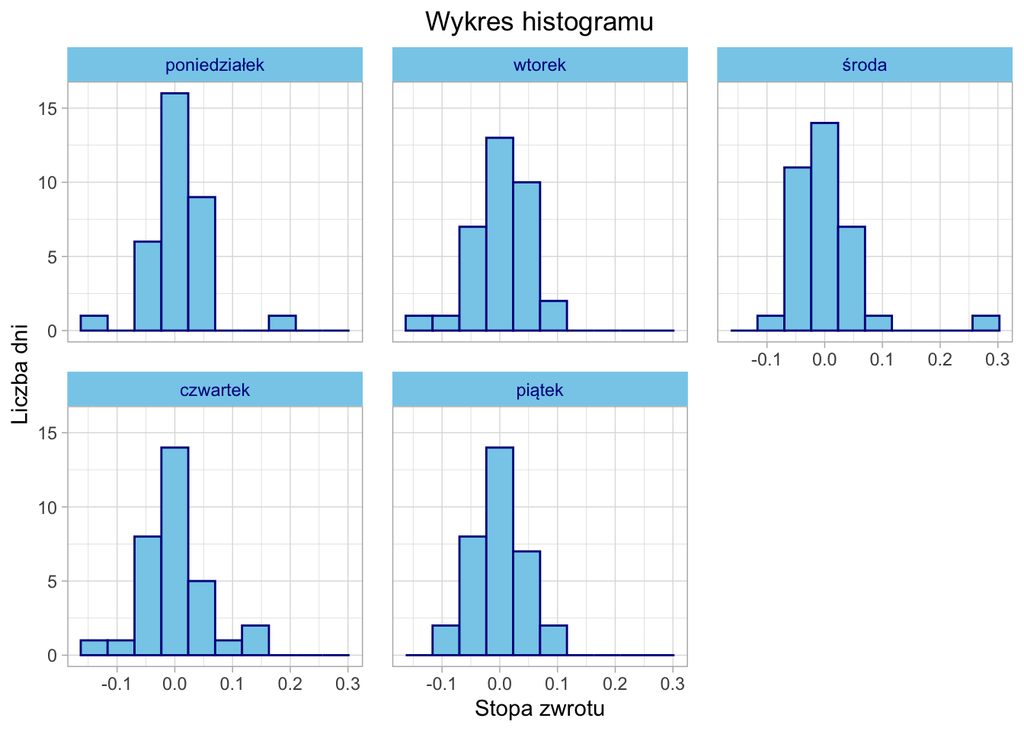

```r
akcje_3 %>%
  ggplot() +
  geom_histogram(aes(x = `Stopa zwrotu`),
                 color = "darkblue",
                 fill = "skyblue",
                 bins = 10) +
  facet_wrap(~ `Dzień tygodnia`,
             ncol = 3) +
  theme_light() +
  theme(plot.title = element_text(hjust = 0.5),
        strip.background = element_rect(fill = "skyblue"),
        strip.text = element_text(color = "darkblue"),
        panel.spacing = unit(1, "lines")) +
  labs(title = "Wykres histogramu",
       x = "Stopa zwrotu",
       y = "Liczba dni")
```

## Wykresy pudełkowe

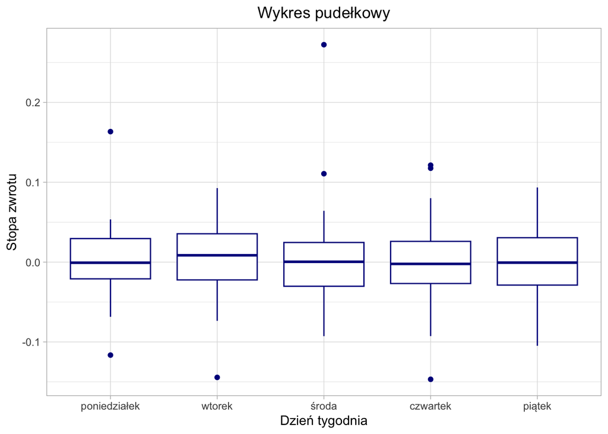

```r
akcje_3 %>%
  ggplot() +
  geom_boxplot(aes(x = `Stopa zwrotu`, y = `Dzień tygodnia`),
                 color = "darkblue") +
  coord_flip() +
  theme_light() +
  theme(plot.title = element_text(hjust = 0.5)) +
  labs(title = "Wykres pudełkowy",
       x = "Stopa zwrotu")
```

Wykresy pudełkowe również potwierdzają powyższe stwierdzenia. W środę oraz czwartek jest najwięcej outlierów znajdujących się nad pudełkiem, które mogą wskazywać na fakt, że to właśnie w ten dzień zdarzają się najczęściej duże stopy zwrotu. Natomiast mediana stóp zwrotów oraz kwartyl górny wydają się przyjmować najwyższe wyniki we wtorki.

## Analiza wariancji

### ANOVA

Teraz przejdziemy do analizy wariancji ANOVA, aby zbadać równość wartości oczekiwanych stóp zwrotu w poszczególnych dniach tygodnia.

```r
anova <- aov(akcje_3$`Stopa zwrotu` ~ akcje_3$`Dzień tygodnia`)
summary(anova)
```

```
##                           Df Sum Sq   Mean Sq F value Pr(>F)
## akcje_3$`Dzień tygodnia`   4 0.0012 0.0002905   0.108  0.979
## Residuals                162 0.4343 0.0026807
```

P-value jest większa niż poziom istotności 0.05, co oznacza, że nie ma podstaw do odrzucenia hipotezy zerowej. Hipoteza zerowa zakłada równość średnich stóp zwrotu między dniami tygodnia.

Teraz przejdziemy do sprawdzenia założeń ANOVA do których należą:

```
Test normalności
Test homogeniczności wariancji
```

### Pochodzenie danych z rozkładu normalnego

Z pomocą tutaj przychodzi funkcja tapply, dzięki której możemy zastosować test Shapiro-Wilka dla danych dotyczących stóp zwrotu w zależności od dnia tygodnia.

```r
tapply(akcje_3$`Stopa zwrotu`, akcje_3$`Dzień tygodnia`, shapiro.test)
```

```
## $poniedziałek
##
##  Shapiro-Wilk normality test
##
## data:  X[[i]]
## W = 0.93701, p-value = 0.05564
##
##
## $wtorek
##
##  Shapiro-Wilk normality test
##
## data:  X[[i]]
## W = 0.95758, p-value = 0.2065
##
##
## $środa
##
##  Shapiro-Wilk normality test
##
## data:  X[[i]]
## W = 0.81462, p-value = 3.999e-05
##
##
## $czwartek
##
##  Shapiro-Wilk normality test
##
## data:  X[[i]]
## W = 0.96549, p-value = 0.385
##
##
## $piątek
##
##  Shapiro-Wilk normality test
##
## data:  X[[i]]
## W = 0.98312, p-value = 0.8743
```

Test normalności sugeruje, że dane tylko w przypadku środy nie pochodzą z rozkładu normalnego.

### Homogeniczność wariancji

Następnym założeniem ANOVA jest homogeniczność wariancji, którą w pakiecie R możemy sprawdzić korzystając z funkcji bartlett.test. W tym przypadku test ten został wykorzystany do oceny równości wariancji w stopach zwrotu w zależności od dnia tygodnia.

```r
bartlett.test(akcje_3$`Stopa zwrotu` ~ akcje_3$`Dzień tygodnia`)
```

```
##
##  Bartlett test of homogeneity of variances
##
## data:  akcje_3$`Stopa zwrotu` by akcje_3$`Dzień tygodnia`
## Bartlett's K-squared = 6.5158, df = 4, p-value = 0.1638
```

Wynik ten nie dostarcza podstaw do odrzucenia hipotezy zerowej o homogeniczności wariancji. Oznacza to, że założenie o równości wariancji w poszczególnych dniach tygodnia jest spełnione.

### Wnioski

Na podstawie przeprowadzonej analizy ANOVA oraz weryfikacji założeń, nie ma statystycznie istotnych różnic w wartościach oczekiwanych stóp zwrotu dla danych pochodzących z dni: poniedziałek, wtorek, czwartek oraz piątek. Wyniki analizy ANOVA nie dostarczają podstaw do odrzucenia hipotezy zerowej, co sugeruje, że średnie stopy zwrotu dla wymienionych dni nie różnią się istotnie.

# Analiza dla pełnej próbki

## Charakterystyki rozkładu dla każdego dnia tygodnia

```r
dni <- akcje %>%
  select(`Dzień tygodnia`, `Stopa zwrotu`) %>%
  group_by(`Dzień tygodnia`) %>%
  summarize(ŚREDNIA = mean(`Stopa zwrotu`),
            ODCHYLENIE = sd(`Stopa zwrotu`),
            SKOŚNOŚĆ = skew(`Stopa zwrotu`),
            KURTOZA = kurtosi(`Stopa zwrotu`))
dni
```

| Dzień tygodnia | ŚREDNIA | ODCHYLENIE | SKOŚNOŚĆ | KURTOZA |
| --- | --- | --- | --- | --- |
| poniedziałek | 0.001051245 | 0.03791949 | 0.23130610 | 3.2070613 |
| wtorek | 0.002762987 | 0.03741297 | 0.13414525 | 3.2268185 |
| środa | 0.003211736 | 0.04460579 | 1.87489628 | 11.6955800 |
| czwartek | -0.002855297 | 0.03987904 | -0.19612988 | 2.6451433 |
| piątek | -0.002317759 | 0.03245485 | 0.06634423 | 0.6480714 |

Analiza wskazuje, że średnie stopy zwrotu różnią się w zależności od dnia tygodnia. W środę rozkład stóp zwrotu wykazuje największą zmienność i asymetrię.

## Histogramy

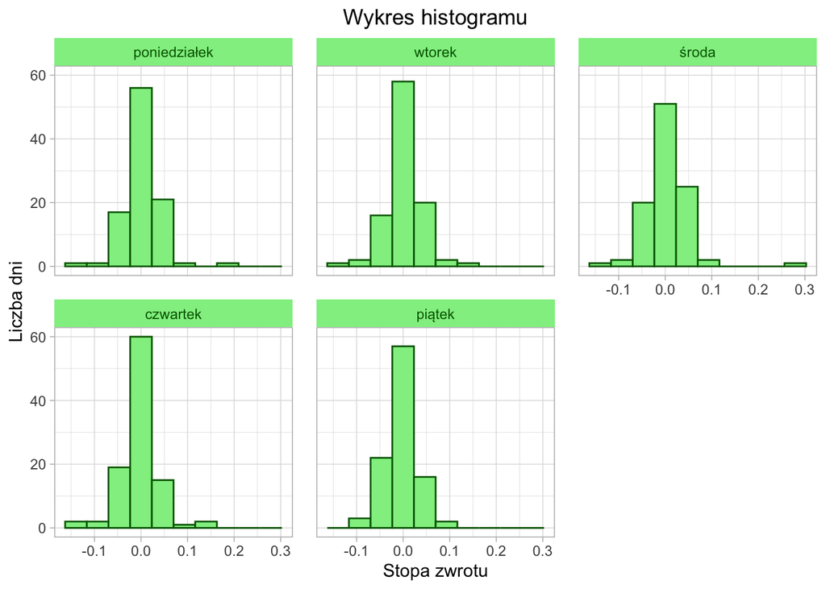

```r
akcje %>%
  ggplot() +
  geom_histogram(aes(x = `Stopa zwrotu`),
                 color = "darkgreen",
                 fill = "lightgreen",
                 bins = 10) +
  facet_wrap(~ `Dzień tygodnia`,
             ncol = 3) +
  theme_light() +
  theme(plot.title = element_text(hjust = 0.5),
        strip.background = element_rect(fill = "lightgreen"),
        strip.text = element_text(color = "darkgreen"),
        panel.spacing = unit(1, "lines")) +
  labs(title = "Wykres histogramu",
       x = "Stopa zwrotu",
       y = "Liczba dni")
```

Pomimo zbliżonych średnich stóp zwrotu bliskich zeru, histogramy dla poszczególnych dni tygodnia różnią się pod względem szerokości i asymetrii. Środa wydaje się być dniem charakteryzującym się większym zakresem i obecnością dni z wyższymi stawkami zwrotu, podczas gdy pozostałe dni są bardziej skupione wokół zera, z niewielkimi fluktuacjami. Środa może przynosić zatem większe szanse na zyski, ale jednocześnie niesie ze sobą większe ryzyko ze względu na większą zmienność. Pozostałe dni tygodnia są bardziej stabilne.

## Wykresy pudełkowe

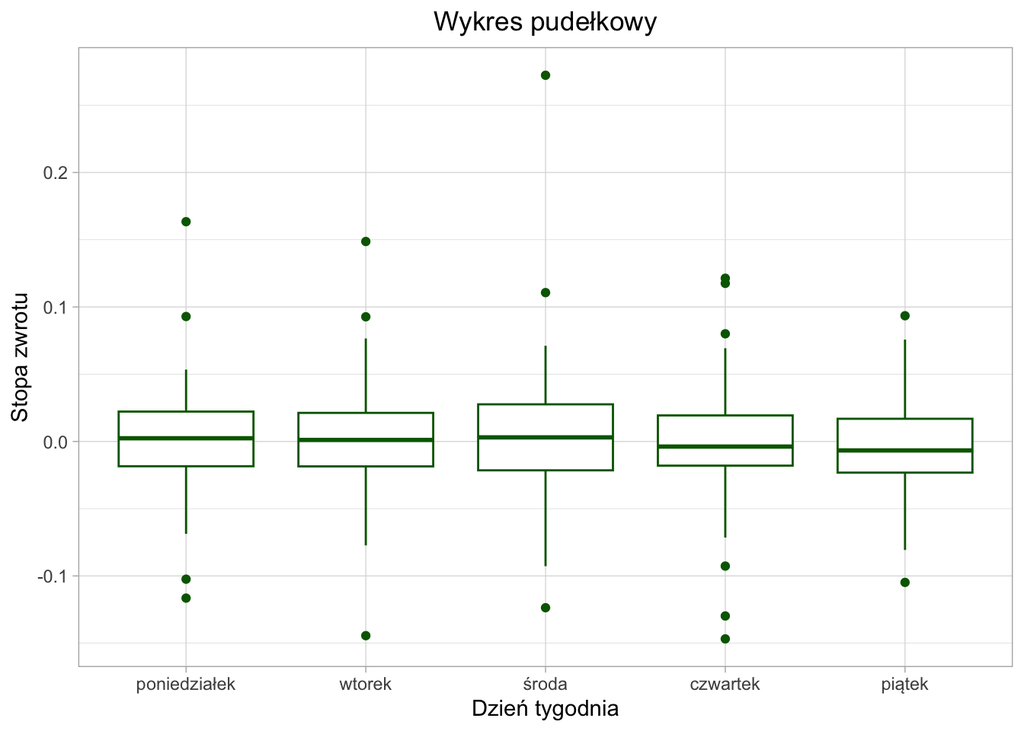

```r
akcje %>%
  ggplot() +
  geom_boxplot(aes(x = `Stopa zwrotu`, y = `Dzień tygodnia`),
                 color = "darkgreen") +
  coord_flip() +
  theme_light() +
  theme(plot.title = element_text(hjust = 0.5)) +
  labs(title = "Wykres pudełkowy",
       x = "Stopa zwrotu")
```

W przeciwieństwie do 1/3 próbki, już na samym początku możemy zauważyć większą ilość wartości odstających. Możemy również zaobserwować, że największa outlier występuje w środę, co bezpośrednie uzasadnienie znajduje w poprzednich statystykach opisowych i histogramach. Zmianom uległy także długości pudełka oraz wąsów.

## Analiza wariancji

### ANOVA

Teraz, przejdziemy do analizy wariancji ANOVA, aby zbadać równość wartości oczekiwanych stóp zwrotu w poszczególnych dniach tygodnia.

```r
anova <- aov(akcje$`Stopa zwrotu` ~ akcje$`Dzień tygodnia`)
summary(anova)
```

```
##                         Df Sum Sq   Mean Sq F value Pr(>F)
## akcje$`Dzień tygodnia`   4 0.0032 0.0008037   0.537  0.709
## Residuals              496 0.7423 0.0014966
```

P-value jest większe niż 0.05, więc nie ma podstaw do odrzucenia hipotezy H0. Na tej podstawie można stwierdzić, że nie ma istotnej różnicy w stopach zwrotu na tym poziomie istotności.

Teraz przejdziemy do sprawdzenia założeń ANOVA do których należą:

```
Test normalności
Test homogeniczności wariancji
```

### Pochodzenie danych z rozkładu normalnego

Przejdźmy do testu normalności.

```r
tapply(akcje$`Stopa zwrotu`, akcje$`Dzień tygodnia`, shapiro.test)
```

```
## $poniedziałek
##
##  Shapiro-Wilk normality test
##
## data:  X[[i]]
## W = 0.94505, p-value = 0.0004604
##
##
## $wtorek
##
##  Shapiro-Wilk normality test
##
## data:  X[[i]]
## W = 0.94906, p-value = 0.00072
##
##
## $środa
##
##  Shapiro-Wilk normality test
##
## data:  X[[i]]
## W = 0.85364, p-value = 1.269e-08
##
##
## $czwartek
##
##  Shapiro-Wilk normality test
##
## data:  X[[i]]
## W = 0.9442, p-value = 0.0003258
##
##
## $piątek
##
##  Shapiro-Wilk normality test
##
## data:  X[[i]]
## W = 0.98542, p-value = 0.3406
```

Analizując powyższe wyniki naszego testu, można stwierdzić, że tylko w piątek poziom p-value przekroczył wartość 0.05, więc w ten dzień brakuje podstaw do odrzucenia hipotezy H0 o normalności rozkładu. Co do reszty dni, hipotezę H0 możemy odrzucić i zakładać brak normalności danych.

### Homogeniczność wariancji

Następnie sprawdzamy, czy wariancje dla poszczególnych dni różnią się od siebie.

```r
bartlett.test(akcje$`Stopa zwrotu` ~ akcje$`Dzień tygodnia`)
```

```
##
##  Bartlett test of homogeneity of variances
##
## data:  akcje$`Stopa zwrotu` by akcje$`Dzień tygodnia`
## Bartlett's K-squared = 10.404, df = 4, p-value = 0.03414
```

Wyniki testu Bartletta dostarczają podstawy do odrzucenia hipotezy zerowej o równości wariancji między grupami. Oznacza to, że wariancje stóp zwrotu różnią się w zależności od dnia tygodnia.

### Wnioski

Ze względu na fakt, że nie wszystkie założenia do testu ANOVA zostały spełnione, jej wyniki nie są wiążące.

# Podsumowanie